[figure not shown]

# Using Dropout for Classification Assignment

in this lab, you will see how adding dropout to your model will decrease overfitting by using `nn.Sequential` and Cross Entropy Loss.

Make Some Data

Create the Model and Cost Function the Pytorch way

Batch Gradient Descent

Estimated Time Needed: **20 min**

Import all the libraries that you need for the lab:

```python
import torch
import matplotlib.pyplot as plt
import torch.nn as nn
import torch.nn.functional as F
import numpy as np
from matplotlib.colors import ListedColormap
```

Use this function only for plotting:

```python
def plot_decision_regions_3class(data_set,model=None):

    cmap_light = ListedColormap(['#FFAAAA', '#AAFFAA','#00AAFF'])
    cmap_bold = ListedColormap(['#FF0000', '#00FF00','#00AAFF'])
    X=data_set.x.numpy()
    y=data_set.y.numpy()
    h = .02
    x_min, x_max = X[:, 0].min()-0.1 , X[:, 0].max()+0.1
    y_min, y_max = X[:, 1].min()-0.1 , X[:, 1].max() +0.1
    xx, yy = np.meshgrid(np.arange(x_min, x_max, h),np.arange(y_min, y_max, h))
    newdata=np.c_[xx.ravel(), yy.ravel()]

    #XX=torch.torch.Tensor(newdata)
    #_,yhat=torch.max(model(XX),1)
    #yhat=yhat.numpy().reshape(xx.shape)

    Z=data_set.fun(newdata).flatten()
    f=np.zeros(Z.shape)
    f[Z>0]=1
    f=f.reshape(xx.shape)
    if model!=None:
        model.eval()
        XX=torch.torch.Tensor(newdata)
        _,yhat=torch.max(model(XX),1)
        yhat=yhat.numpy().reshape(xx.shape)
        plt.pcolormesh(xx, yy, yhat, cmap=cmap_light)
        plt.contour(xx, yy, f, cmap=plt.cm.Paired)
    else:
        plt.contour(xx, yy, f, cmap=plt.cm.Paired)
        plt.pcolormesh(xx, yy, f, cmap=cmap_light)

    plt.title("decision region vs True decision boundary")
    plt.legend()
```

Use this function to calculate accuracy:

```python
def accuracy(model,data_set):
    _,yhat=torch.max(model(data_set.x),1)
    return (yhat==data_set.y).numpy().mean()
```

## Get Some Data

Create a nonlinearly separable dataset:

```python
from torch.utils.data import Dataset, DataLoader

class Data(Dataset):
    def __init__(self,N_SAMPLES = 1000,noise_std=0.1,train=True):

        a=np.matrix([-1,1,2,1,1,-3,1]).T

        self.x = np.matrix(np.random.rand(N_SAMPLES,2))

        self.f=np.array(a[0]+(self.x)*a[1:3]+np.multiply(self.x[:,0], self.x[:,1])*a[4]+np.multiply(self.x, self.x)*a[5:7]).flatten()
        self.a=a

        self.y=np.zeros(N_SAMPLES)
        self.y[self.f> 0]=1
        self.y=torch.from_numpy(self.y).type(torch.LongTensor)
        self.x=torch.from_numpy(self.x).type(torch.FloatTensor)
        self.x = self.x+noise_std*torch.randn(self.x.size())
        self.f=torch.from_numpy(self.f)
        self.a=a
        if train==True:
            torch.manual_seed(1)

            self.x = self.x+noise_std*torch.randn(self.x.size())
            torch.manual_seed(0)


    def __getitem__(self,index):
        return self.x[index],self.y[index]
    def __len__(self):
        return self.len
    def plot(self):
        X=data_set.x.numpy()
        y=data_set.y.numpy()
        h = .02
        x_min, x_max = X[:, 0].min() , X[:, 0].max()
        y_min, y_max = X[:, 1].min(), X[:, 1].max()
        xx, yy = np.meshgrid(np.arange(x_min, x_max, h),np.arange(y_min, y_max, h))
        Z=data_set.fun(np.c_[xx.ravel(), yy.ravel()]).flatten()
        f=np.zeros(Z.shape)
        f[Z>0]=1
        f=f.reshape(xx.shape)
        plt.title('True decision boundary  and sample points with noise ')


        plt.plot(self.x[self.y==0,0].numpy(),self.x[self.y==0,1].numpy(),'bo',label='y=0' )
        plt.plot(self.x[self.y==1,0].numpy(), self.x[self.y==1,1].numpy(),'ro',label='y=1' )
        plt.contour(xx, yy, f, cmap=plt.cm.Paired)
        plt.xlim(0,1)
        plt.ylim(0,1)
        plt.legend()
    def fun(self,x):

        x=np.matrix(x)

        out=np.array(self.a[0]+(x)*self.a[1:3]+np.multiply(x[:,0], x[:,1])*self.a[4]+np.multiply(x, x)*self.a[5:7])
        out=np.array(out)
        return out
```

Create a dataset object:

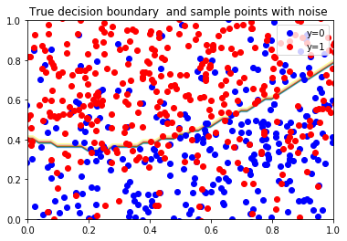

```python
data_set=Data(noise_std=0.2)
data_set.plot()
```

Get some validation data:

```python
torch.manual_seed(0)
validation_set=Data(train=False)
```

## Create the Model, Optimizer, and Total Loss Function (cost)

### Create a three-layer neural network `model` with a ReLU() activation function for regression. All the appropriate layers should be 300 units.

```python
hidden = 300
model = nn.Sequential(
    nn.Linear(in_features=2, out_features=hidden),
    nn.ReLU(),
    nn.Linear(in_features=hidden, out_features=hidden),
    nn.ReLU(),
    nn.Linear(in_features=hidden, out_features=2)
)
```

Double-click **here** for the solution.

### Create a three-layer neural network `model_drop` with a ReLU() activation function for regression. All the appropriate layers should be 300 units. Apply dropout to all but the last layer and make the probability of dropout is 50%.

```python
p = 0.5
model_drop = nn.Sequential(
    nn.Linear(2, hidden),
    nn.Dropout(p=p),
    nn.ReLU(),
    nn.Linear(hidden, hidden),
    nn.Dropout(p=p),
    nn.ReLU(),
    nn.Linear(hidden, 2)
)
```

Double-click **here** for the solution.

Set the model by using dropout to training mode; this is the default mode, but it's a good practice.

```python
model_drop.train()
```

```
Sequential(
  (0): Linear(in_features=2, out_features=300, bias=True)
  (1): Dropout(p=0.5)
  (2): ReLU()
  (3): Linear(in_features=300, out_features=300, bias=True)
  (4): Dropout(p=0.5)
  (5): ReLU()
  (6): Linear(in_features=300, out_features=2, bias=True)
)
```

Train the model by using the Adam optimizer. See the unit on other optimizers. Use the Cross Entropy Loss:

```python
optimizer_ofit = torch.optim.Adam(model.parameters(), lr=0.01)
optimizer_drop = torch.optim.Adam(model_drop.parameters(), lr=0.01)
criterion = torch.nn.CrossEntropyLoss()
```

## Create the appropriate loss function.

Initialize a dictionary that stores the training and validation loss for each model:

```python
LOSS={}
LOSS['training data no dropout']=[]
LOSS['validation data no dropout']=[]
LOSS['training data dropout']=[]
LOSS['validation data dropout']=[]
```

```python
print(accuracy)
```

```
<function accuracy at 0x7fccc0e8d8c8>
```

Set the model with dropout to evaluation mode:

```python
model_drop.eval()
```

```
Sequential(
  (0): Linear(in_features=2, out_features=300, bias=True)
  (1): Dropout(p=0.5)
  (2): ReLU()
  (3): Linear(in_features=300, out_features=300, bias=True)
  (4): Dropout(p=0.5)
  (5): ReLU()
  (6): Linear(in_features=300, out_features=2, bias=True)
)
```

### Test the accuracy of the model without dropout on the validation data.

```python
print(accuracy(model, validation_set))
```

```
0.881
```

Double-click **here** for the solution.

```python
print(accuracy(model_drop, validation_set))
```

```
0.906
```

Double-click **here** for the solution.

You see that the model with dropout performs better on the validation data.

Plot the decision boundary and the prediction of the networks in different colors:

## true function

```
No handles with labels found to put in legend.
```

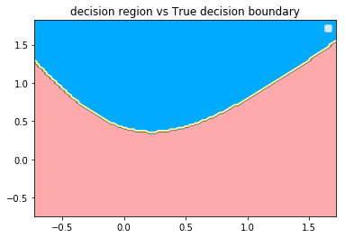

```python
plot_decision_regions_3class(data_set)
```

## model without dropout

```
No handles with labels found to put in legend.
```

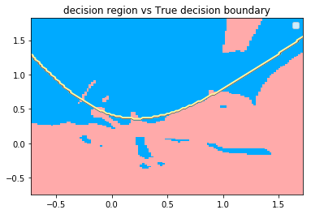

```python
plot_decision_regions_3class(data_set,model)
```

## model with dropout

```
No handles with labels found to put in legend.
```

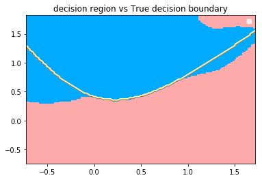

```python
plot_decision_regions_3class(data_set,model_drop)
```

You can see that the model using dropout does better at tracking the function that generated the data.

Plot out the loss for training and validation data on both models:

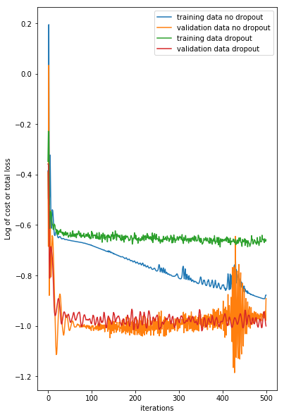

```python
plt.figure(figsize=(6.1, 10))
for key, value in LOSS.items():
    plt.plot(np.log(np.array(value)),label=key)
    plt.legend()
    plt.xlabel("iterations")
    plt.ylabel("Log of cost or total loss")
```

You see that the model without dropout performs better on the training data, but it performs worse on the validation data. This suggests overfitting. However, the model using dropout performed better on the validation data, but worse on the training data.

[figure not shown]

### About the Authors:

[Joseph Santarcangelo](https://www.linkedin.com/in/joseph-s-50398b136/) has a PhD in Electrical Engineering. His research focused on using machine learning, signal processing, and computer vision to determine how videos impact human cognition.

Other contributors: [Michelle Carey](https://www.linkedin.com/in/michelleccarey/), [Morvan Youtube channel](https://www.youtube.com/channel/UCdyjiB5H8Pu7aDTNVXTTpcg), [Mavis Zhou](https://www.linkedin.com/in/jiahui-mavis-zhou-a4537814a/)

Copyright © 2018 cognitiveclass.ai. This notebook and its source code are released under the terms of the [MIT License](https://bigdatauniversity.com/mit-license/).